# Analysis of nuMt allele frequencies

Richard Nichols

21/12/2020

## Pre-processing in the data

### Initial parameter choices

```r
# The lowest average frequency the minor allele
cutoff <- 0.01
# The no. of SNPs to sample (glmer gets indigestion with the full dataset)
snpNo <- 200

# mixed effects library with the lmer function
library(lme4)
# knitr utilities
library(knitr)
```

### Raw data

The datafile (read from github.com/qmwugbt112/nuMt-analysis), gives

- **mapDep**: the proportion of all reads that are mtDNA-like (i.e. are either organellar or nuMt)
- counts of
  - **main**: the main allele (i.e. the one shared with organellar DNA sequence)
  - **alt**: alternate allele (i.e. the one restricted to nuMt DNA sequences)
- names for
  - the **SNP**
  - the **individual** insect sampled
- **polymorphic**: a boolean variable identifying sites thought to be polymorphic in the organellar mitochondrial DNA (which would muddy the analysis).

Raw data

| X | mapDep | main | alt | SNP | individual | polymorphic |
| --- | --- | --- | --- | --- | --- | --- |
| 1 | 0.0008992 | 21 | 0 | S00001 | 10T | FALSE |
| 2 | 0.0014914 | 43 | 0 | S00001 | 11T | FALSE |
| 3 | 0.0010401 | 29 | 0 | S00001 | 12T | FALSE |
| 4 | 0.0010148 | 15 | 0 | S00001 | 13T | FALSE |
| 5 | 0.0008153 | 10 | 0 | S00001 | 14T | FALSE |
| 6 | 0.0007695 | 13 | 0 | S00001 | 15T | FALSE |
| 7 | 0.0016769 | 48 | 1 | S00001 | 16T | FALSE |

### Initial filtering

These three plots show

- The distribution of raw allele frequency data for each SNP across all individuals
- The truncated data (Frequencies > 1%)
- The sub-sampled data (SNPs selected in proportion to their frequency)

Subsampling is required because so the lmer function will run. Higher-frequency alleles are more informative about the proportion of the nuclear genome that is nuMt DNA, so they more heavily sampled. However we wish to cover the whole frequency spectruum; in case rare alleles show different trends, for example.

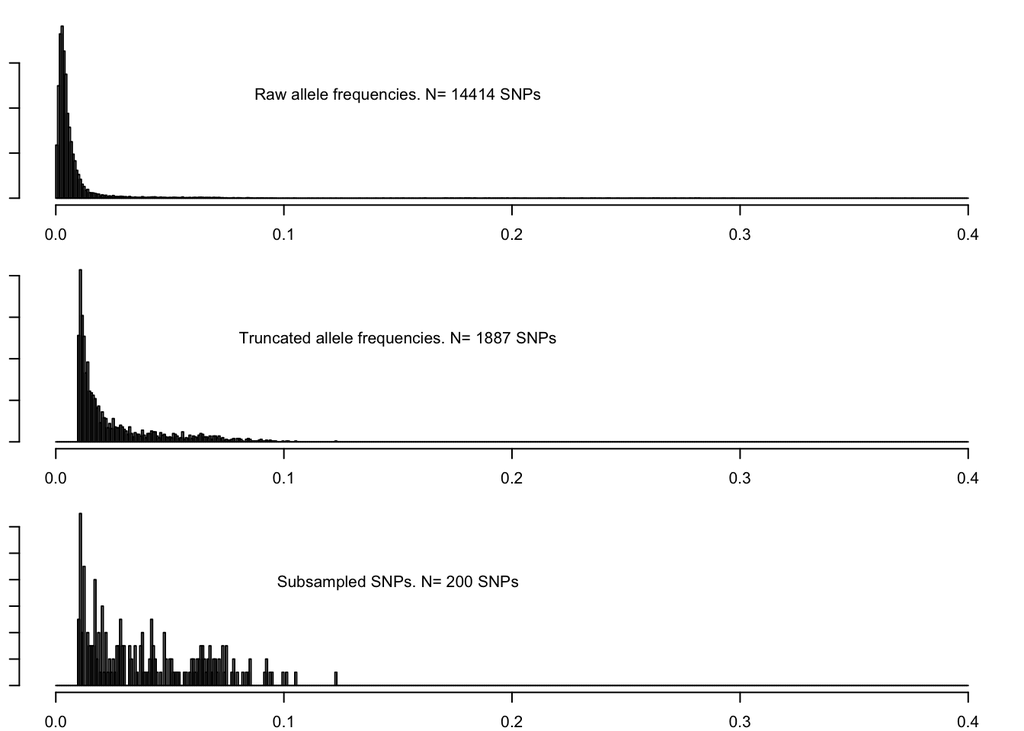

### Viewing the subsampled data

Consequently a plot of $log(p_{obs})$ aginst $-log(c+m)$ should have a slope of 1 and an intercept of $log(p_n) + log(c)$. It will vary among alleles, and the SNPs with a higher value of $p_n$ give a lower bound on $c$.

An inital plot shows most loci fit a 1:1 relationships (Lines are the 1:1 plots with the highest and lowest intercept), but with some outliers (indicated). The older data, sequenced with a different technology, fit a similar relationship, but the observed frequencies are higher, especially for the rarer alleles. Consequently the two datasets were treated separately in the subsequent analysis.

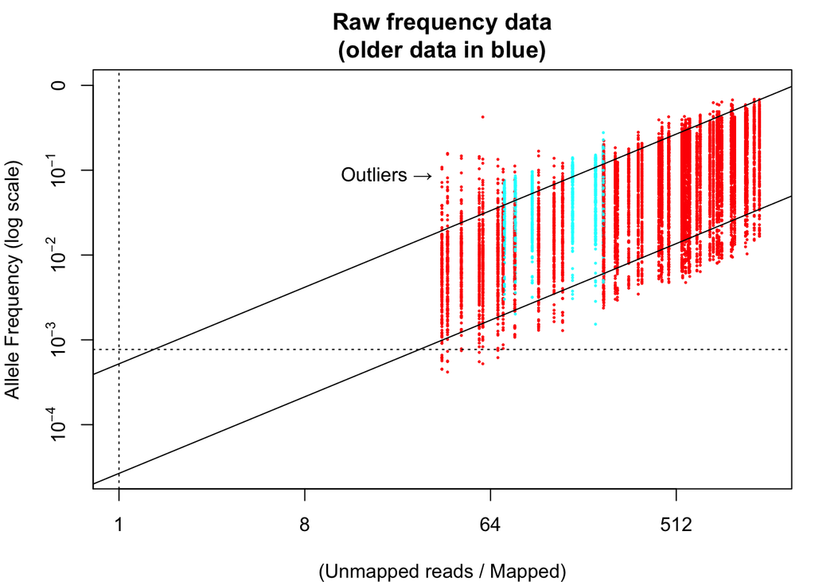

### Identifying outlying SNP loci

The initial inspection suggested that a subset of loci deviate from the typical regression of log$(p_obs)$ vs -log$(c + m)$. Deviant loci were identified by fitting a mixed effects model with a different slope for each locus:

```
## lmer(formula = yvals ~ SNP + xvals + xvals:SNP + (1 | individual),
##     data = newDat)
```

The outliers were selected by inspection of a histogram of slopes for each SNP.

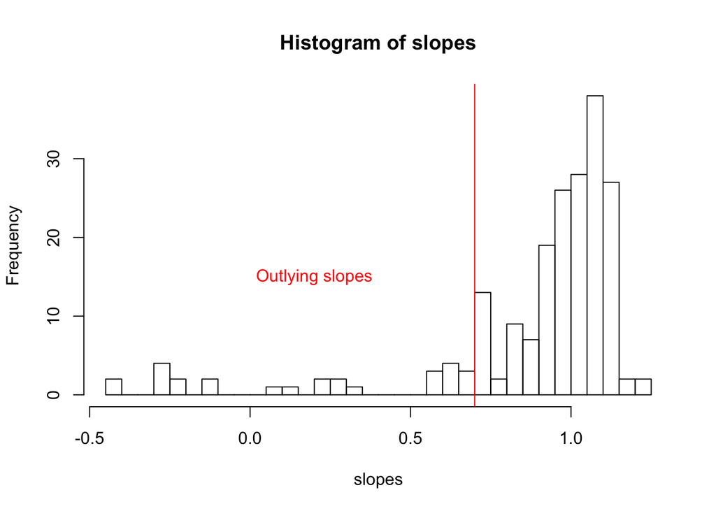

### The regression patterns in the rogue SNPs

The rogue SNPs do not follow the expected 1:1 relationship with -log$(c+m)$ = log(unmapped reads/mapped)

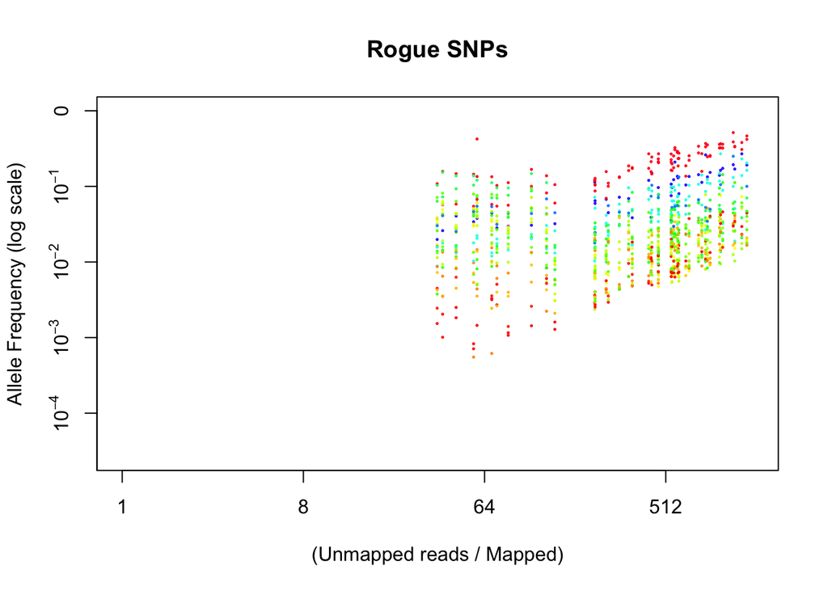

## Estimating the proportion of nuMt DNA in the nucleus The remaining data can be fitted to a model of a 1:1 slope by using $(c+m)$ as an offset. Individual is treated as a random effect. There are two bounds on c: an upper bound estimated from the smallest relative frequency of (c+m) and a lower bound estimated from the highest intercept. The intercept is log($c$) +log($p_n$) so the lower estimate will will be close to $c$ for SNPs with high frequency of the nuMt allele.

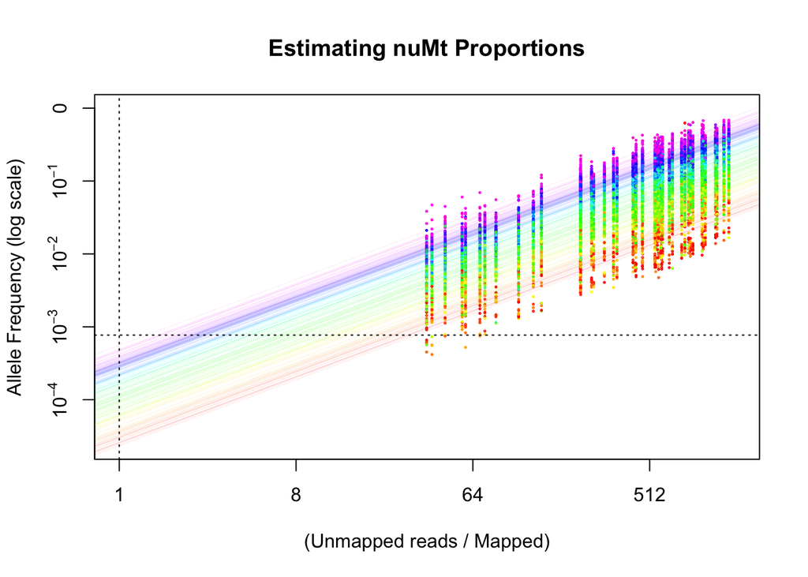

```
## Upper estimate of c  (the lowest of (c+m)):    0.077 %
```

```
## Lower estimate of c  (the highest intercept):    0.056 %
```

### analysis of residual variation

The residual variation is an estimate of the variation of allele frequencies among nuMts, which might have a geographical structure (nearby populations might be expected to have similar frequencies). The residual pattern of residual variation among samples was therefore used to construct a Principle components analysis

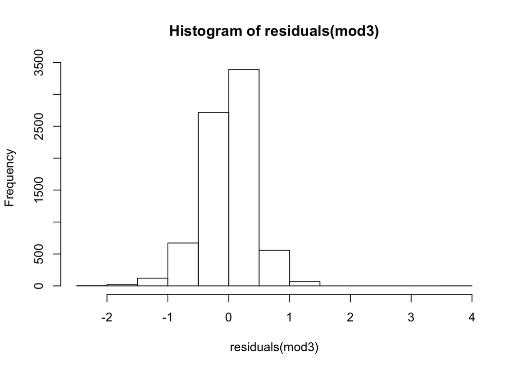

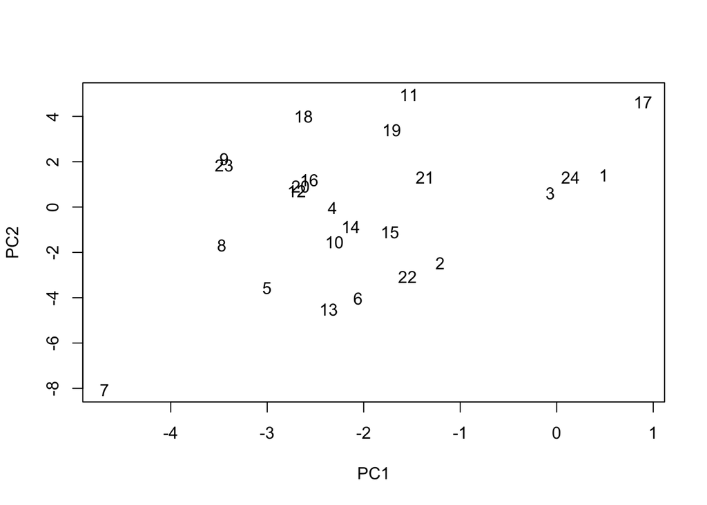

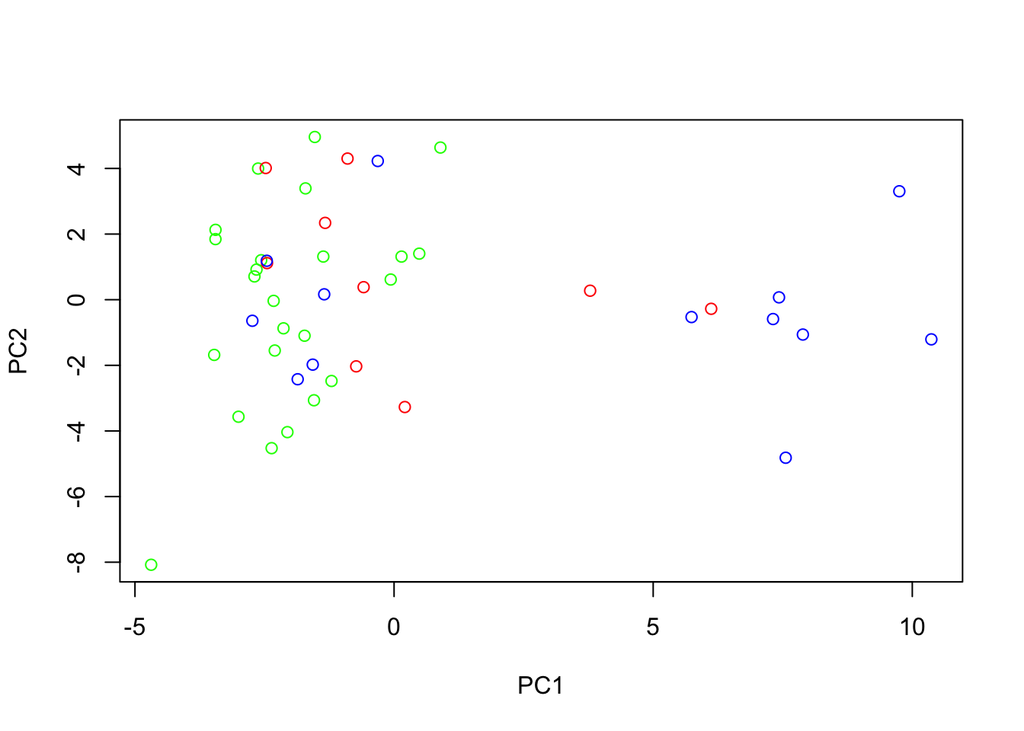